# B211812

稲本倖詞朗

2023-02-09

## 2022年W杯決勝トーナメント進出国とFIFAランキングの関係

＜データを解析する目的＞

2022年サッカーワールドカップ本大会で出場国に対しグループリーグを突破し、決勝トーナメント進出するかどうかということについて当時のFIFAランキングが与える影響を調べる。

<データの背景>

2022年のワールドカップの結果とその当時のFIFAランキング https://www.jfa.jp/samuraiblue/worldcup_2022/team.html

<データの要約>

r=ワールドカップ直前のFIFAランキング(ただし、順位に対して１位から５位までを１、６位から１０位を２、１１位から１５位を３、１６位から２０位を４２１位から２５位を５、２６位から３０位を６、３１位から３５位を７、３６位から４０位を８、４１位から４５位を９、４６位以上を１０とする。)

```r
kadai.df <- read.csv("datafortest.csv",header=TRUE)
summary(kadai.df$r)
```

```
##    Min. 1st Qu.  Median    Mean 3rd Qu.    Max.
##   1.000   2.000   4.000   4.656   6.250  10.000
```

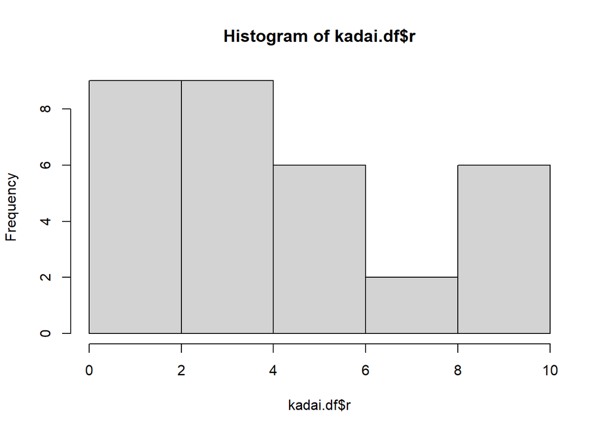

```r
hist(kadai.df$r)
```

<分析手法の選択理由>

目的変数がグループリーグを突破したか否かの２値の値をとるので、ロジスティック回帰分析を行った。

＜分析結果＞

ロジスティック回帰分析の結果とそのグラフ

```r
kadai.df <- read.csv("datafortest.csv",header=TRUE)
kadai.fit <- glm(w ~ r,
                 family = binomial(link = "logit"),
                 data = kadai.df
                 )
summary(kadai.fit)
```

```
##
## Call:
## glm(formula = w ~ r, family = binomial(link = "logit"), data = kadai.df)
##
## Deviance Residuals:
##      Min        1Q    Median        3Q       Max
## -1.72513  -1.00603   0.09346   0.95961   1.71172
##
## Coefficients:
##             Estimate Std. Error z value Pr(>|z|)
## (Intercept)   1.5798     0.7716   2.047   0.0406 *
## r            -0.3478     0.1526  -2.278   0.0227 *
## ---
## Signif. codes:  0 '***' 0.001 '**' 0.01 '*' 0.05 '.' 0.1 ' ' 1
##
## (Dispersion parameter for binomial family taken to be 1)
##
##     Null deviance: 44.361  on 31  degrees of freedom
## Residual deviance: 37.787  on 30  degrees of freedom
## AIC: 41.787
##
## Number of Fisher Scoring iterations: 4
```

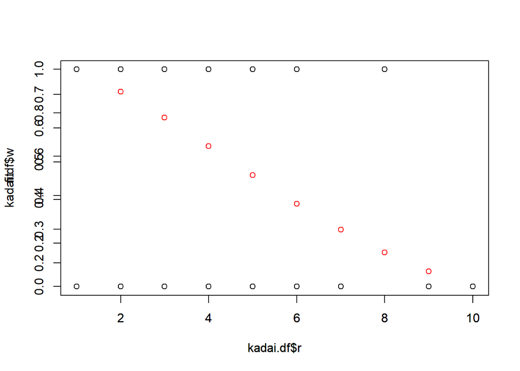

```r
fit=fitted(kadai.fit)
plot(kadai.df$r,fit,col="red")
par(new=TRUE)
plot(kadai.df$r,kadai.df$w)
```

対数オッズとオッズ比

$\log(\frac{\pi}{1-\pi})=1.5798-0.3478x$

$\pi=\frac{\exp(1.5798-0.3478x)}{1+\exp(1.5798-0.3478x)}$

```r
print(exp(1.5798-0.3478)/{1+exp(1.5798-0.3478)})
```

```
## [1] 0.7741684
```

```r
print(exp(1.5798-0.3478*2)/{1+exp(1.5798-0.3478*2)})
```

```
## [1] 0.7076918
```

```r
print(exp(1.5798-0.3478*3)/{1+exp(1.5798-0.3478*3)})
```

```
## [1] 0.6309746
```

```r
print(exp(1.5798-0.3478*4)/{1+exp(1.5798-0.3478*4)})
```

```
## [1] 0.5470107
```

```r
print(exp(1.5798-0.3478*5)/{1+exp(1.5798-0.3478*5)})
```

```
## [1] 0.4602838
```

```r
print(exp(1.5798-0.3478*6)/{1+exp(1.5798-0.3478*6)})
```

```
## [1] 0.3758971
```

```r
print(exp(1.5798-0.3478*7)/{1+exp(1.5798-0.3478*7)})
```

```
## [1] 0.2984269
```

```r
print(exp(1.5798-0.3478*8)/{1+exp(1.5798-0.3478*8)})
```

```
## [1] 0.231013
```

```r
print(exp(1.5798-0.3478*9)/{1+exp(1.5798-0.3478*9)})
```

```
## [1] 0.1750285
```

```r
print(exp(1.5798-0.3478*10)/{1+exp(1.5798-0.3478*10)})
```

```
## [1] 0.1303123
```

$\log(\frac{\pi}{1-\pi})=1.5798-0.3478x$

$\pi=\frac{\exp(1.5798-0.3478x)}{1+\exp(1.5798-0.3478x)}$

検定結果

```r
confint.default(kadai.fit)
```

```
##                   2.5 %      97.5 %
## (Intercept)  0.06752362  3.09216518
## r           -0.64693769 -0.04857821
```

```r
exp(confint.default(kadai.fit))
```

```
##                 2.5 %     97.5 %
## (Intercept) 1.0698555 22.0247140
## r           0.5236469  0.9525828
```

```r
drop1(kadai.fit,test="LRT")
```

```
## Single term deletions
##
## Model:
## w ~ r
##        Df Deviance    AIC    LRT Pr(>Chi)
## <none>      37.787 41.787
## r       1   44.361 46.361 6.5741  0.01035 *
## ---
## Signif. codes:  0 '***' 0.001 '**' 0.01 '*' 0.05 '.' 0.1 ' ' 1
```

```r
confint.default(kadai.fit)
```

```
##                   2.5 %      97.5 %
## (Intercept)  0.06752362  3.09216518
## r           -0.64693769 -0.04857821
```

```r
exp(confint.default(kadai.fit))
```

```
##                 2.5 %     97.5 %
## (Intercept) 1.0698555 22.0247140
## r           0.5236469  0.9525828
```

```r
kadai.predlin <- predict(kadai.fit,type="link",se.fit=TRUE)
kadai.predlin$fit
```

```
##          1          2          3          4          5          6          7
## -1.8977351 -1.5499771  0.1888126  0.8843285  1.2320865  0.1888126  0.1888126
##          8          9         10         11         12         13         14
##  0.1888126  1.2320865 -1.8977351  0.5365706 -0.5067033  1.2320865 -1.2022192
##         15         16         17         18         19         20         21
##  0.8843285 -0.5067033  0.8843285 -0.8544612  0.5365706 -0.1589453  1.2320865
##         22         23         24         25         26         27         28
## -1.5499771 -0.1589453  0.5365706  1.2320865 -0.1589453  0.5365706 -1.5499771
##         29         30         31         32
##  0.8843285 -1.8977351  0.5365706 -0.5067033
```

```r
kadai.predlin$se.fit
```

```
##         1         2         3         4         5         6         7         8
## 0.9479903 0.8115718 0.3968429 0.5321915 0.6449817 0.3968429 0.3968429 0.3968429
##         9        10        11        12        13        14        15        16
## 0.6449817 0.9479903 0.4439092 0.4670612 0.6449817 0.6820654 0.5321915 0.4670612
##        17        18        19        20        21        22        23        24
## 0.5321915 0.5642509 0.4439092 0.4056040 0.6449817 0.8115718 0.4056040 0.4439092
##        25        26        27        28        29        30        31        32
## 0.6449817 0.4056040 0.4439092 0.8115718 0.5321915 0.9479903 0.4439092 0.4670612
```